# SDS/CSC 293 Mini-Project 3: Multiple Regression

Group 9: Karen Santamaria, Sophia Tannir

Wednesday, March 27<sup>th</sup>, 2019

You will be submiting an entry to Kaggle’s [DonorsChoose.org Application Screening: Predict whether teachers’ project proposals are accepted](https://www.kaggle.com/c/donorschoose-application-screening/) by fitting a **logistic regression** model $\hat{f}(x)$.

# EDA

Read in data provided by Kaggle for this competition. They are organized in the `data/` folder of this RStudio project:

```r
training <- read_csv("data/train.csv")
test <- read_csv("data/test.csv")
sample_submission <- read_csv("data/sample_submission.csv")
```

Before performing any model fitting, you should always conduct an exploratory data analysis. This will help guide and inform your model fitting.

## Look at your data!

Always, ALWAYS, **ALWAYS** start by looking at your raw data. This gives you visual sense of what information you have to help build your predictive models. To get a full description of each variable, read the data dictionary in the `data_description.txt` file in the `data/` folder.

Note that the following code chunk has `eval = FALSE` meaning “don’t evaluate this chunk with knitting” because `.Rmd` files won’t knit if they include a `View()`:

```r
View(training)
glimpse(training)

View(test)
glimpse(test)
```

In particular, pay close attention to the variables and variable types in the `sample_submission.csv`. Your submission must match this exactly.

```r
glimpse(sample_submission)
```

```
## Observations: 78,035
## Variables: 2
## $ id                  <chr> "p233245", "p096795", "p236235", "p233680", …
## $ project_is_approved <dbl> 0.8476823, 0.8476823, 0.8476823, 0.8476823, …
```

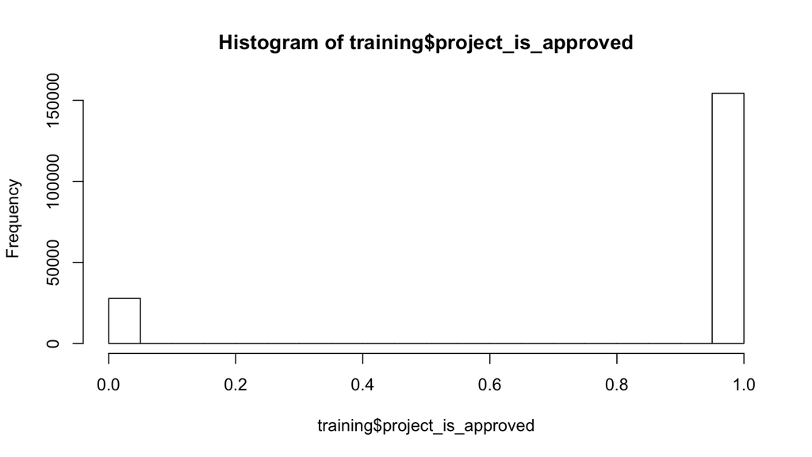

```r
hist(training$project_is_approved)
```

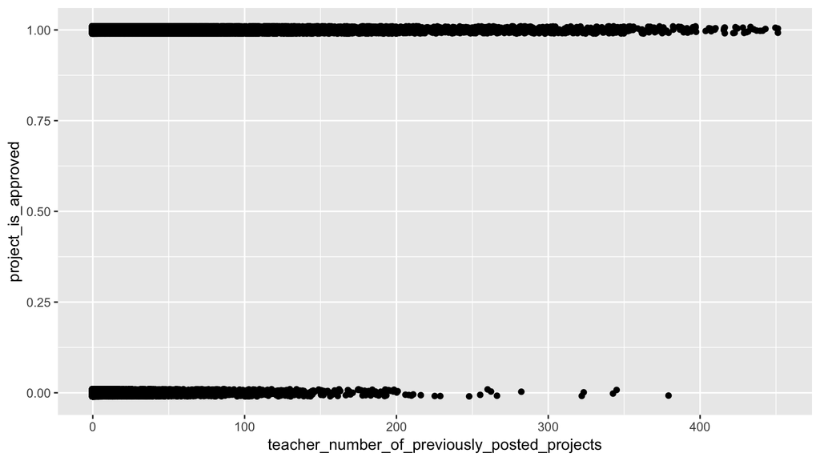

```r
ggplot(data = training, aes(x=teacher_number_of_previously_posted_projects, y=project_is_approved)) +
  geom_jitter(height=0.01)
```

## Data wrangling

As much as possible, try to do all your data wrangling here:

```r
training$project_grade_category <- as.factor(training$project_grade_category)
training$project_grade_category <- relevel(training$project_grade_category, "Grades PreK-2")
test$project_grade_category <- as.factor(test$project_grade_category)
test$project_grade_category <- relevel(test$project_grade_category, "Grades PreK-2")
training$project_subject_categories <- as.factor(training$project_subject_categories)
test$project_subject_categories <- as.factor(test$project_subject_categories)
training$teacher_prefix <- as.factor(training$teacher_prefix)
test$teacher_prefix <- as.factor(test$teacher_prefix)
```

# Minimally viable product

## Fit model on training

Fit a logistic regression model $\widehat{f}_1$ with only an intercept term on all the training data. In other words, your model will not use any predictor variables. Save this in `model_1`. What is the uniquely fitted probability?

```r
model_1 <- glm(project_is_approved~1, data= training, family = binomial())
```

## Estimate of your Kaggle score

Use the `yardstick` package to get an estimate of your Kaggle score: the area under the ROC curve (AUC). Crossvalidation is not necessary as with no predictor variables, we are in very little danger of overfitting the model.

```r
fitted_points_model_1 <- model_1 %>%
  broom::augment()
```

```r
fitted_points_model_1 <- fitted_points_model_1 %>%
  mutate(
    fitted_prob = 1/(1 + exp(-.fitted)),
    fitted_prob_inverse = 1/(1 + exp(.fitted))

    )

roc_auc(fitted_points_model_1, as.factor(project_is_approved), fitted_prob_inverse)
```

| .metric | .estimator | .estimate |
| --- | --- | --- |
| roc_auc | binary | 0.5 |

## Make predictions on test

Apply your `model_1` fitted model to the test data. What is the uniquely predicted probability?

```r
predict_model_1 <- model_1 %>%
  broom::augment(newdata = test)
```

## Create your submission CSV

```r
submission <- test %>%
  mutate(
    project_is_approved = exp(predict_model_1$.fitted)/(1+exp(predict_model_1$.fitted))
    ) %>%
  select(id, project_is_approved)


write_csv(submission, path = "data/submission_model_1.csv")
```

## Screenshot of your Kaggle score

Our score based on our submission’s “Area under the Receiver Operating Characteristic Curve” was 0.500.

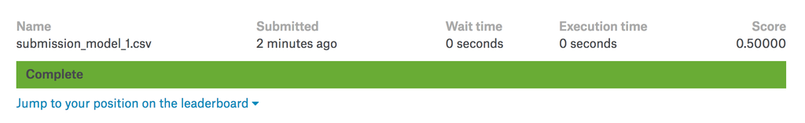

# Due diligence

## Plot ROC curve

Use the `yardstick` package to plot the ROC curve:

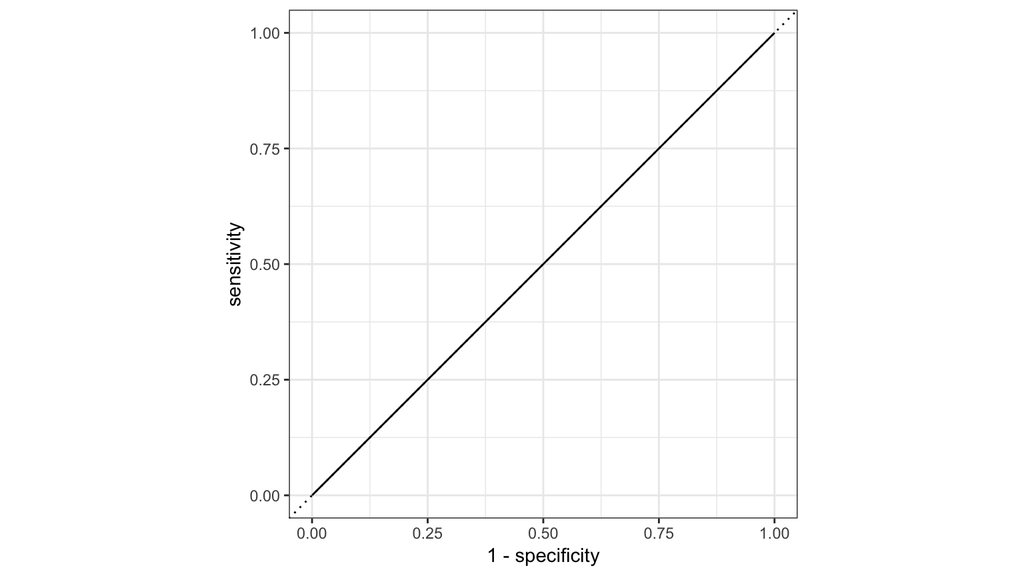

```r
autoplot(roc_curve(fitted_points_model_1, as.factor(project_is_approved), fitted_prob_inverse ))
```

# Reaching for the stars

## Fit model on training

Fit a logistic regression model $\widehat{f}_2$ using a single numerical predictor variable $x$ on all the training data. Save this in `model_2`. Then display a single visualization that shows:

- The relationship between outcome variable $y$ and your numerical predictor variable $x$ with black points
- The relationship between the fitted probabilities $\widehat{p}$ from model $\widehat{f}_2$ and your numerical predictor variable $x$ with a red curve
- The fitted probabilities $\widehat{p}$ from model $\widehat{f}_1$ with a horizontal blue line at the same time.

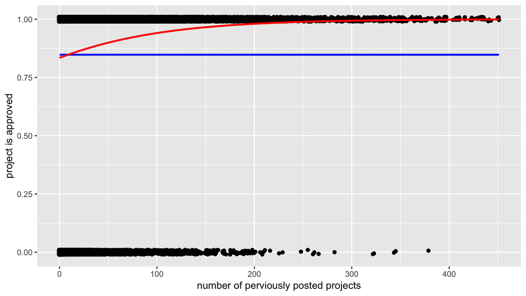

```r
model_2 <- glm(project_is_approved ~ teacher_number_of_previously_posted_projects, data= training, family = binomial())





fitted_points_model_2 <- model_2 %>%
  broom::augment()

fitted_points_model_2 <- fitted_points_model_2 %>%
    mutate(
    fitted_prob = 1/(1 + exp(-.fitted)),
    fitted_prob_inverse = 1/(1 + exp(.fitted))
    )



fitted_points_model_1$teacher_number_of_previously_posted_projects <- training$teacher_number_of_previously_posted_projects

ggplot(data = fitted_points_model_2, aes(x=teacher_number_of_previously_posted_projects, y=project_is_approved)) +
  geom_jitter(height=0.01) +
  geom_line(data = fitted_points_model_1, mapping = aes(y = fitted_prob), col = "blue", size = 1) + #plot model_1 probabilities
  geom_line(data = fitted_points_model_2, mapping = aes(y = fitted_prob), col = "red", size = 1) + #plot model_2 probabilities
  labs(x = "number of perviously posted projects", y = "project is approved")
```

## Estimate of your Kaggle score

Use the `yardstick` package to get an estimate of your Kaggle score: the area under the ROC curve (AUC). Crossvalidation is not necessary as with only 1 predictor variable and so many points, we are in very little danger of overfitting the model.

```r
roc_auc(fitted_points_model_2, as.factor(project_is_approved), fitted_prob_inverse)
```

| .metric | .estimator | .estimate |
| --- | --- | --- |
| roc_auc | binary | 0.5607127 |

## Make predictions on test

Apply your `model_2` fitted model to the test data and display a histogram of the predicted probabilities.

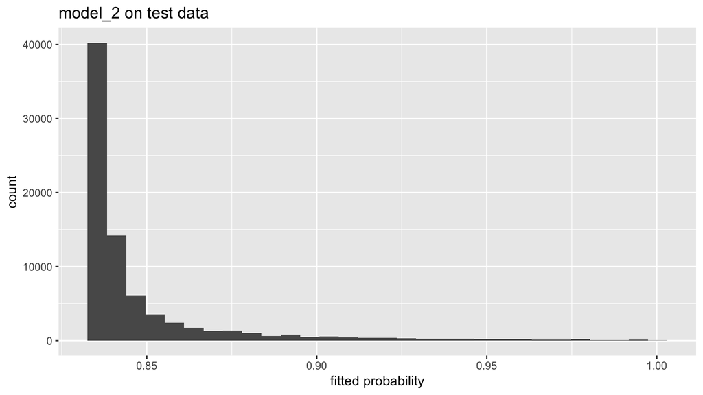

```r
predict_model_2 <- model_2 %>%
  broom::augment(newdata = test)

predict_model_2 <- predict_model_2 %>%
  mutate(
    fitted_prob = exp(predict_model_2$.fitted)/(1+exp(predict_model_2$.fitted))
    )


ggplot(data=predict_model_2, aes(predict_model_2$fitted_prob)) +
  geom_histogram() +
  labs(x = "fitted probability", title = "model_2 on test data")
```

## Create your submission CSV

```r
submission2 <- test %>%
  mutate(project_is_approved = predict_model_2$fitted_prob) %>%
  select(id, project_is_approved)



write_csv(submission2, path = "data/submission_model_2.csv")
```

## Screenshot of your Kaggle score

Our score based on our submission’s “Area under the Receiver Operating Characteristic Curve” was 0.56522.

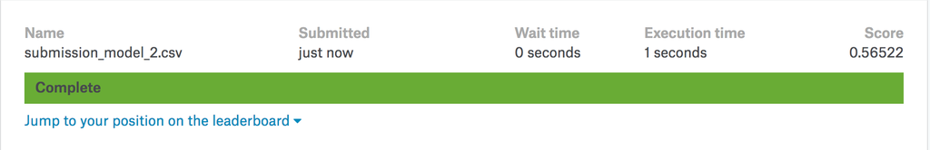

## Plot ROC curve

Use the `yardstick` package to plot the ROC curve:

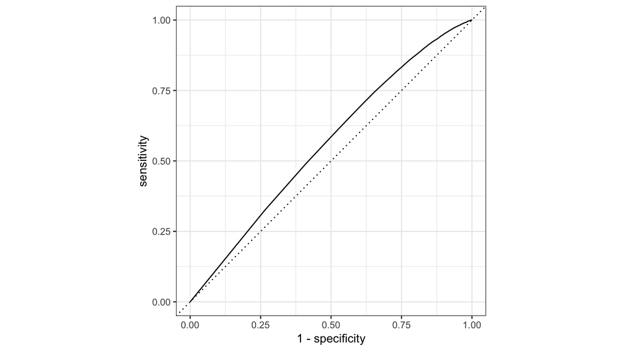

```r
autoplot(roc_curve(fitted_points_model_2, as.factor(project_is_approved), fitted_prob_inverse ))
```

# Point of diminishing returns

## Fit model on training

Fit a logistic regression model $\widehat{f}_3$ using a single categorical predictor variable $x$ on all the training data. Save this in `model_3`. Then display a single visualization that shows:

- The relationship between the fitted probabilities $\widehat{p}$ from model $\widehat{f}_3$ and your categorical predictor variable $x$
- The fitted probabilities $\widehat{p}$ from model $\widehat{f}_1$ with a horizontal blue line at the same time.

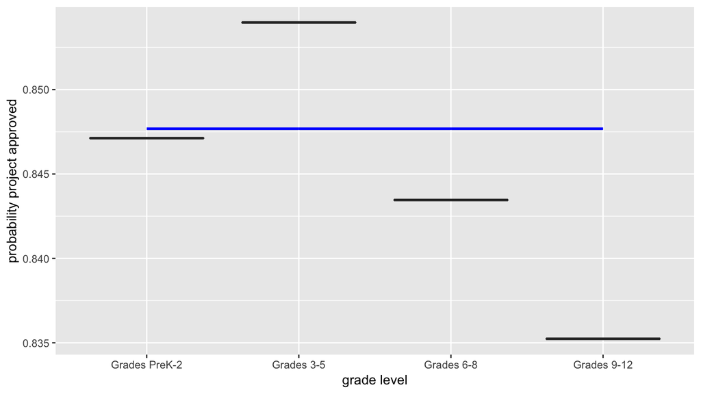

```r
model_3 <- glm(project_is_approved ~ project_grade_category, data= training, family = binomial())


fitted_points_model_3 <- model_3 %>%
  broom::augment()

fitted_points_model_3 <- fitted_points_model_3 %>%
    mutate(
    fitted_prob = 1/(1 + exp(-.fitted)),
    fitted_prob_inverse = 1/(1 + exp(.fitted))
    )


fitted_points_model_1$project_grade_category <- training$project_grade_category



ggplot(data = fitted_points_model_3, aes(x=project_grade_category, y=fitted_prob)) +
  geom_boxplot() +
  geom_line(
    data = fitted_points_model_1, mapping = aes(y = fitted_prob, x =  project_grade_category, group=1 ),
    col = "blue", size = 1) +
    labs(x = "grade level", y = "probability project approved")
```

## Estimate of your Kaggle score

Use the `yardstick` package to get an estimate of your Kaggle score: the area under the ROC curve (AUC). Crossvalidation is not necessary as with only 1 predictor variable and so many points, we are in very little danger of overfitting the model.

```r
roc_auc(fitted_points_model_3, as.factor(project_is_approved), fitted_prob_inverse)
```

| .metric | .estimator | .estimate |
| --- | --- | --- |
| roc_auc | binary | 0.5115242 |

## Make predictions on test

Apply your `model_3` fitted model to the test data and display a histogram of the predicted probabilities.

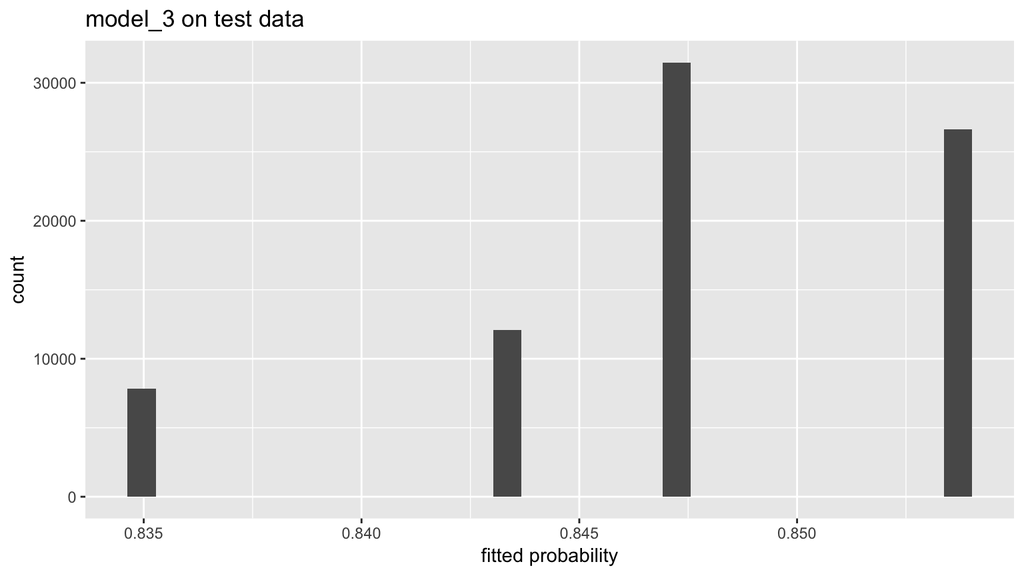

```r
predict_model_3 <- model_3 %>%
  broom::augment(newdata = test)

predict_model_3 <- predict_model_3 %>%
  mutate(
    fitted_prob = exp(predict_model_3$.fitted)/(1+exp(predict_model_3$.fitted))
    )

ggplot(data=predict_model_3, aes(fitted_prob)) +
  geom_histogram() +
  labs(x = "fitted probability", title = "model_3 on test data")
```

## Create your submission CSV

```r
submission3 <- test %>%
  mutate(project_is_approved = predict_model_3$fitted_prob) %>%
  select(id, project_is_approved)



write_csv(submission3, path = "data/submission_model_3.csv")
```

## Screenshot of your Kaggle score

Our score based on our submission’s “Area under the Receiver Operating Characteristic Curve” was 0.51156.

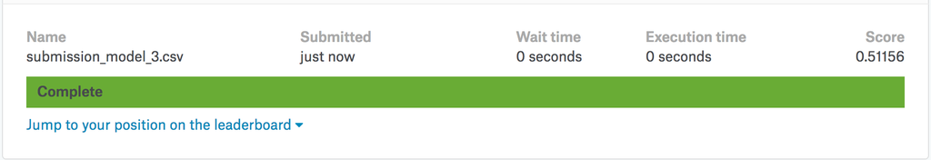

## Plot ROC curve

Use the `yardstick` package to plot the ROC curve:

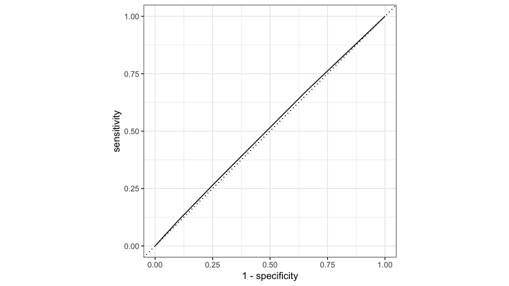

```r
autoplot(roc_curve(fitted_points_model_3, as.factor(project_is_approved), fitted_prob_inverse ))
```

# Polishing the cannonball

## Fit model on training

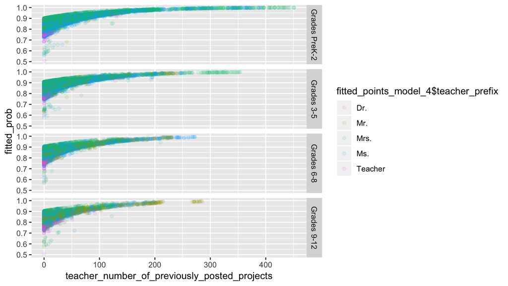

```r
model_4 <- glm(project_is_approved ~ project_grade_category + teacher_number_of_previously_posted_projects + project_subject_categories + teacher_prefix, data= training, family = binomial())


fitted_points_model_4 <- model_4 %>%
  broom::augment()

fitted_points_model_4 <- fitted_points_model_4 %>%
    mutate(
      fitted_prob = exp(fitted_points_model_4$.fitted)/(1+exp(fitted_points_model_4$.fitted)),
      fitted_inverse = 1/(1 + exp(.fitted))
    )


ggplot(data = fitted_points_model_4, aes(x=teacher_number_of_previously_posted_projects, y=fitted_prob)) +
  geom_point(aes(color = fitted_points_model_4$teacher_prefix), alpha = 0.1) +
  facet_grid(fitted_points_model_4$project_grade_category~.) +
  coord_cartesian(ylim = c(0.5,1))
```

## Estimate of your Kaggle score

```r
roc_auc(fitted_points_model_4, as.factor(project_is_approved), fitted_inverse)
```

| .metric | .estimator | .estimate |
| --- | --- | --- |
| roc_auc | binary | 0.5846857 |

## Make predictions on test

Apply your `model_4` fitted model to the test data and display a histogram of the predicted probabilities.

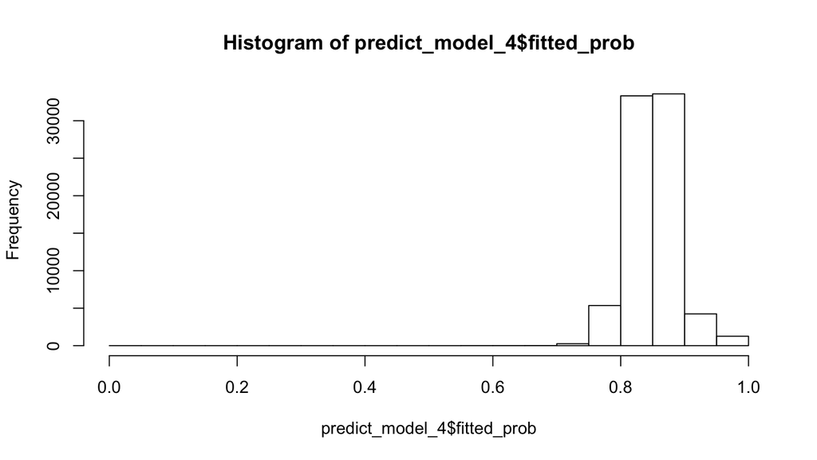

```r
predict_model_4 <- model_4 %>%
  broom::augment(newdata = test)

predict_model_4 <- predict_model_4 %>%
  mutate(
    fitted_prob = exp(predict_model_4$.fitted)/(1+exp(predict_model_4$.fitted))
    )


hist(predict_model_4$fitted_prob)
```

## Create your submission CSV

```r
submission4 <- test %>%
  mutate(project_is_approved = predict_model_4$fitted_prob) %>%
  select(id, project_is_approved)

submission4$project_is_approved[is.na(submission4$project_is_approved)] <- 0.85

write_csv(submission4, path = "data/submission_model_4.csv")
```

## Screenshot of your Kaggle score

Our score based on our submission’s “Area under the Receiver Operating Characteristic Curve” was 0.58931.

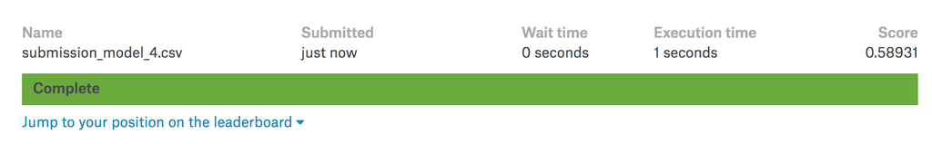

## Plot ROC Curve

Use the `yardstick` package to plot the ROC curve:

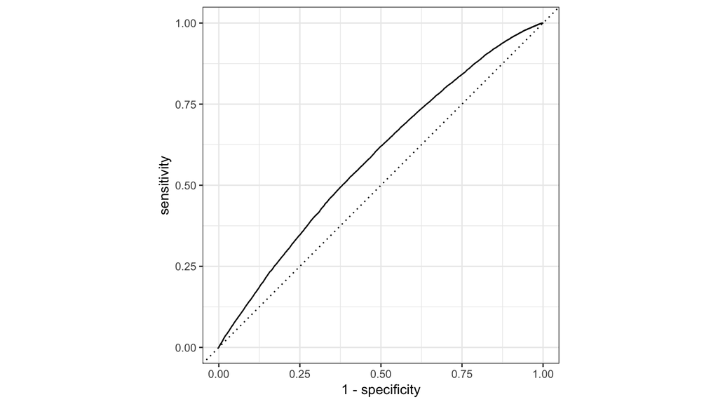

```r
autoplot(roc_curve(fitted_points_model_4, as.factor(project_is_approved), fitted_inverse ))
```